# MSCA-37014-Python-For-Analytics-Group-Project

This repository contains the information about the group project for **MScA 37014 Python for Analytics**.

**Professor:** **Shahbaz Chaudhary**

[figure not shown]

**Team:**

- **[Albert Seo](https://www.linkedin.com/in/albert-young-seo-01254a89/)** (aseo@uchicago.edu)
- **[Matt Kendall](https://www.linkedin.com/in/mtkendall/)** (mkendall@uchicago.edu)
- **[Oleksiy Anokhin](https://www.linkedin.com/in/oanokhin/)** (anokhin@uchicago.edu)
- **[Surendiran Rangaraj](https://www.linkedin.com/in/surendiran-rangaraj-29463119/)** (surendiran@uchicago.edu)

Our data-driven journalist department **(Alberto Seo | Matt Kendall | Oleksiy Anokhin | Surendiran Rangaraj)** at the **Gargoyle Times** delivered a data-driven report, having explored Foreign Labor Certification data by the U.S. Department of Labor.

**Data source:** https://www.foreignlaborcert.doleta.gov/performancedata.cfm#dis

In this report our team analyzed information about foreign workers on the US labor marker and data about their labor certification by the US federal agency.

Trying to understand the situation with the certification of foreign workers, our department asked the following questions:

**Question 1: Origin and Education of Workers**

- What are the countries of origin of foreign workers?
- Which univerisities supply foreign workers for the US labor market and how much?

**Question 2: Acceptance Rate and Timing of Applications**

- What are the acceptance rates in percentages and which factors affect it?
- What is the waiting time for the procedure and which factors affect it?
- How does this information related to salaries of workers?
- How much applications are denied and what are the patterns?

**Examples of analysis**

**1. Visualize world countries by the number of applicants**

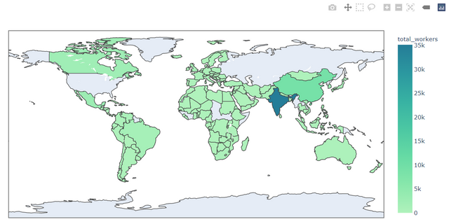

**2. Universities, supplying the biggest number of foreign workers**

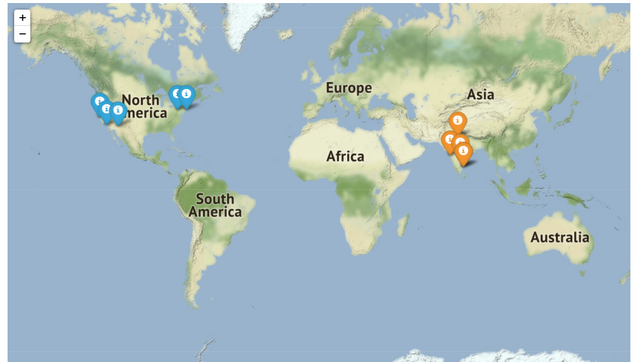

**3. Average time (in months) for case duration per country of citizenship**

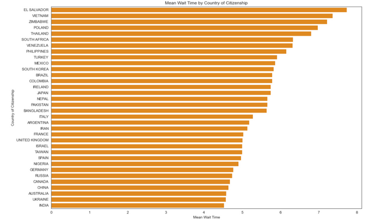

**4. Acceptance rate by minimum education required**

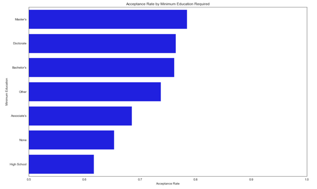

**5. Relationship between the salary size, professional level, and case results**

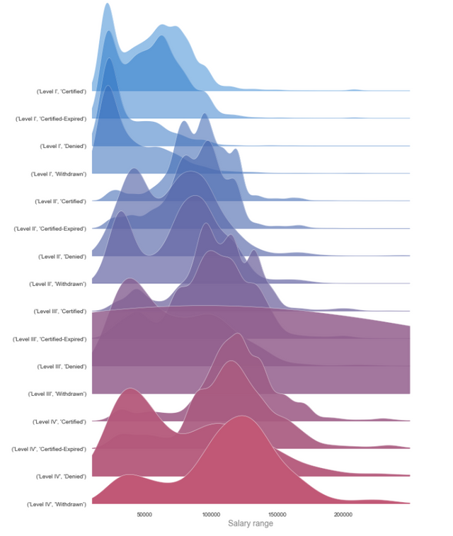

**Additional information - Useful information for organizing GitHub repositories:**

[GitHub template for organizing files for data analysis](https://github.com/AndersenLab/IBiS-Bootcamp/wiki/Organizing-files-for-data-analysis)